# Chapter 6, Statistical Model

# 1. AR모형

### AR모형 적합 - 자동

```r
demand= read.table('Daily_Demand_Forecast.txt', sep = ';', head=T)


fit = ar(demand$Banking.orders..2., method = 'mle')
fit
```

```
##
## Call:
## ar(x = demand$Banking.orders..2., method = "mle")
##
## Coefficients:
##       1        2        3
## -0.1360  -0.2014  -0.3175
##
## Order selected 3  sigma^2 estimated as  1.414e+09
```

R의 ar 함수는 자동으로 가장 적절한 차수를 가진 ar모형을 찾아 모델을 적합시킨다.

이를 arima함수를 이용해 수동으로 할 수도 있음

### AR 모형 적합 - 수동

```r
getwd()
```

```
## [1] "C:/Users/cross/실전시계열분석/TIMESERIES-ANALYSIS"
```

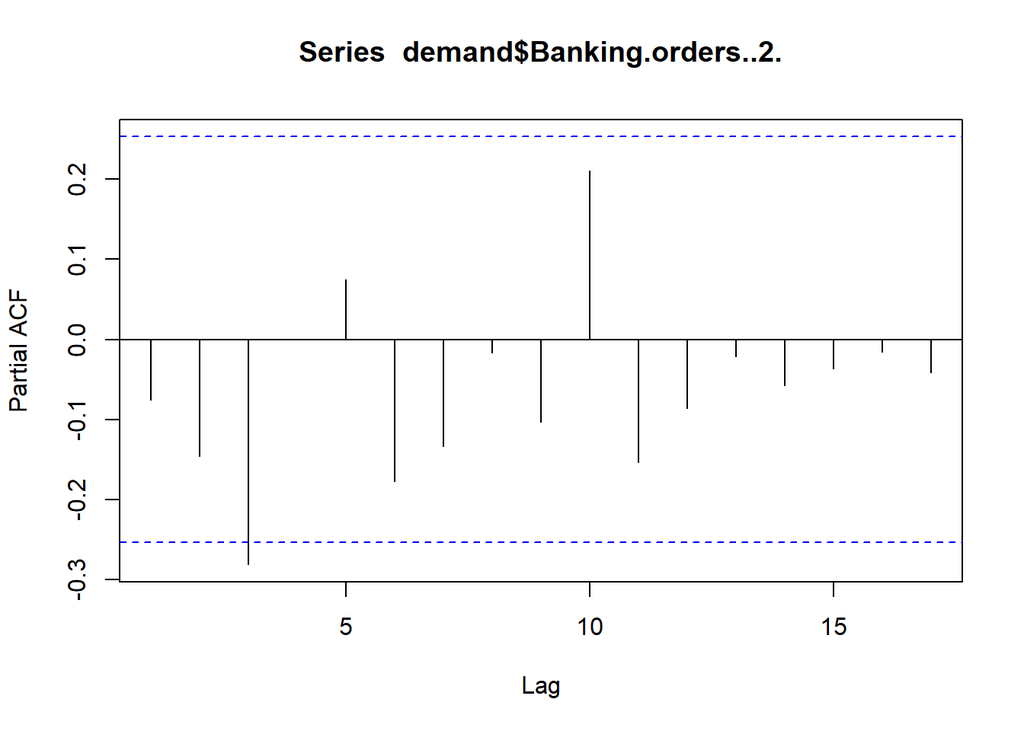

```r
pacf(demand$Banking.orders..2.)
```

```r
est = arima(x=demand$Banking.orders..2., order = c(3,0,0))
est
```

```
##
## Call:
## arima(x = demand$Banking.orders..2., order = c(3, 0, 0))
##
## Coefficients:
##           ar1      ar2      ar3  intercept
##       -0.1358  -0.2013  -0.3176  79075.350
## s.e.   0.1299   0.1289   0.1296   2981.124
##
## sigma^2 estimated as 1.414e+09:  log likelihood = -717.42,  aic = 1444.83
```

PACF를 보면 차수가 3일때 pacf값이 임계값을 넘기므로 AR(3)모형으로 적합시켰다. fixed = c(0,0,NA,NA) argument로 ar1, ar2의 모수를 0으로 제한하고 싶었지만, 이상하게 에러가 떠서 fixed argument는 생략

### AR 모형 평가

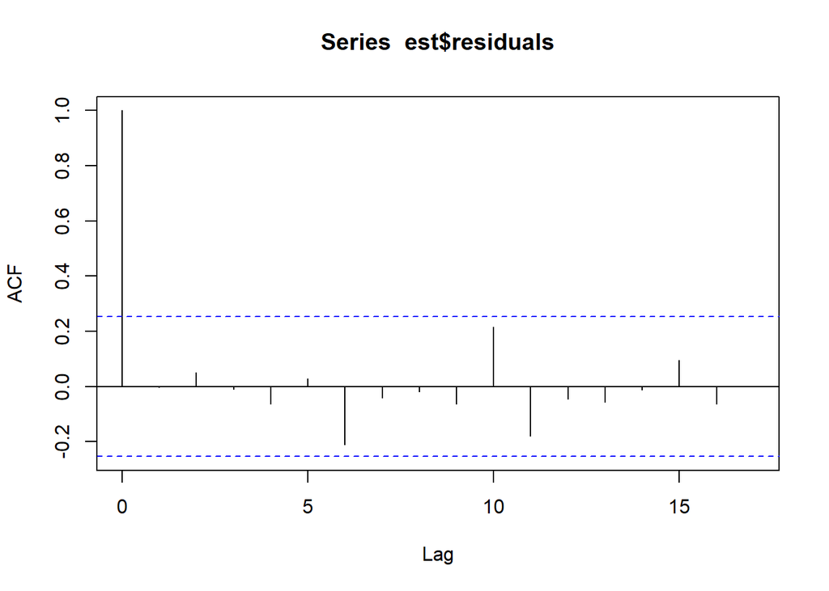

```r
acf(est$residuals)
```

ar모형의 잔차들로 ACF 그래프를 그려보았더니 잔차들의 상관관계가 임계값을 넘지 않은 것으로 보아 위 시계열 데이터를 ar(3)모형에 적합하는 것이 적절하다고 결론 낼 수 있다.

### 적합한 ar 모형으로 미래 예측

```r
require(forecast)
```

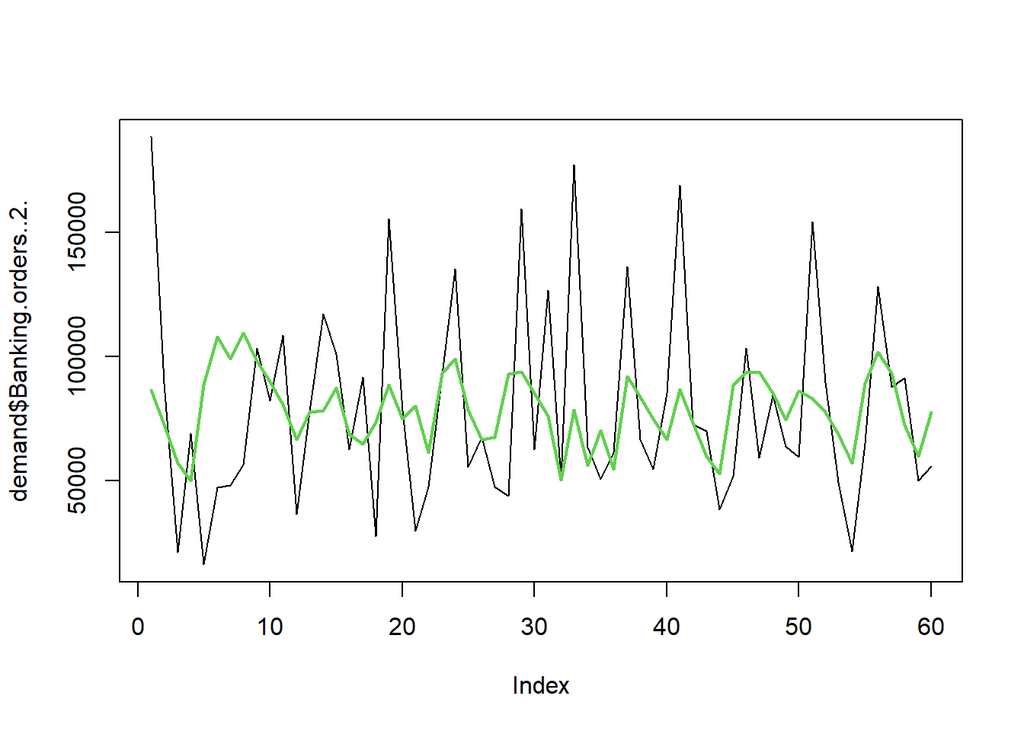

```r
plot(demand$Banking.orders..2., type = 'l')
# fitted는 모델 적합에 사용된 데이터에 대한 예측값!을 반환한다.
# 예측기간을 지정하기 위한 h인수를 추가로 전달할 수 있다.

lines(fitted(est), col =3, lwd=2)
```

```r
fitted(est, h=3)
```

```
## Time Series:
## Start = 1
## End = 60
## Frequency = 1
##  [1]        NA        NA        NA  48382.22  84445.09 101586.53  77720.28
##  [8]  91550.00  81858.40  81089.87  80728.04  69045.88  78835.36  72884.74
## [15]  92885.50  77653.85  66439.20  76232.84  87361.59  75677.57  92734.61
## [22]  55407.19  82405.21  96522.09  83404.08  70101.53  63422.67  90596.32
## [29]  83504.44  85158.34  85218.31  53125.87  87790.19  69810.93  89529.01
## [36]  53498.55  89338.48  91060.07  80558.97  60917.24  85885.43  87847.38
## [43]  74744.00  54279.30  88291.14  86161.96  88732.66  82483.60  68072.43
## [50]  84733.73  77456.37  82420.97  83362.64  56700.83  81119.05  92095.11
## [57]  92600.61  76452.53  61571.38  79910.70
```

## MA 모형

동일데이터로 MA모형에 적합시켜봄

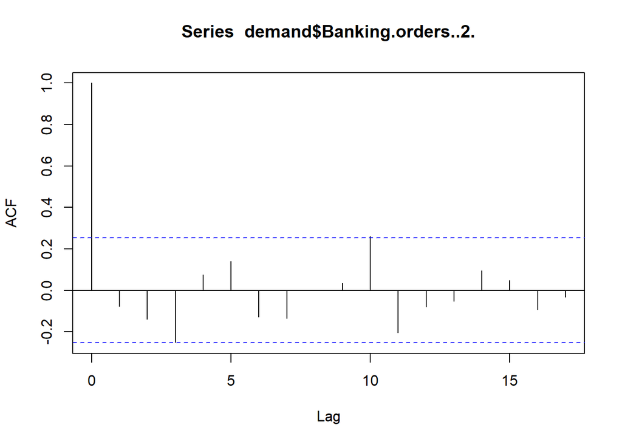

```r
acf(demand$Banking.orders..2.)
```

```r
ma.est = arima(x = demand$Banking.orders..2., order = c(0,0,10),
               fixed = c(0,0,NA,rep(0,6), NA,NA))
ma.est
```

```
##
## Call:
## arima(x = demand$Banking.orders..2., order = c(0, 0, 10), fixed = c(0, 0, NA,
##     rep(0, 6), NA, NA))
##
## Coefficients:
##       ma1  ma2      ma3  ma4  ma5  ma6  ma7  ma8  ma9    ma10  intercept
##         0    0  -0.3744    0    0    0    0    0    0  0.2773  78921.483
## s.e.    0    0   0.1385    0    0    0    0    0    0  0.1367   4092.398
##
## sigma^2 estimated as 1.305e+09:  log likelihood = -715.56,  aic = 1439.11
```

ACF를 그렸을때 시차가 t=3, t=10일때 임계값이 넘는 유의미한 상관관계를 보이고 있으므로 MA모형의 차수를 10으로 하여 모형 적합함

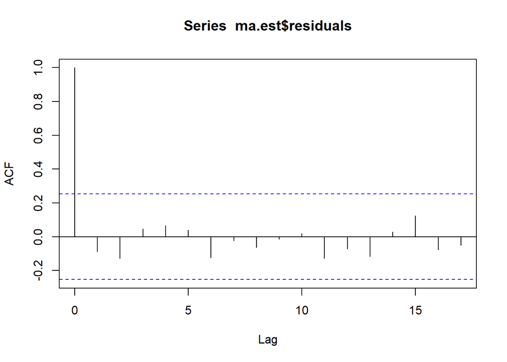

```r
acf(ma.est$residuals)
```

fitting된 ma 모형의 잔차가 그 어떤 상관관계를 보여주지 않고 있다. 이 데이터는 MA(10) 모형으로 데이터를 적합하여 예측하는 것이 적절하다고 결론내린다.

# ARIMA 모형

ARIMA 모델은 정교한 러신머닝 및 딥러닝 모델이 필요없는 소규모 데이터셋에서 좋은 성능을 보여주고 있다.

### ARIMA 모형 수동적합

ARIMA 모형의 파라미터 선택을 위한 발견적 방법들 중 가장 대표적인 ’박스 - 젠킨스’방법 :  
1. 데이터, 시각화, 기반 지식을 사용하여 데이터에 적합한 모델의 종류를 고른다. 2. 주어진 학습용 뎅디터로 파라미터 추정 3. 학습용 데이터를 기반으로 모델 성능을 평가하고, 모데ㅐㄹ의 파라미터를 조정한다.

수동적합 방법은 1. 먼저 모델이 정상시계열인지 아닌지를 파악하고, 추세가 존재한다면 정상시계열로 바꿔질때까지 몇 번 차분이 필요한지 조사한다. 이 과정이 ARIMA(p,d,q)에서 q를 조사해보는 과정 2. ACF와 PACF그래프를 보고 ARIMA(p,d,q) 중 p와 q를 결정한다.

그러나 책에 따르ㅜ면 오늘날에는 수동으로 반복하는 과정보다 모델을 자동으로 선택하는 방법이 더욱 선호된다고 한다. 자동화된 모델의 선택은 forcast 패키지의 auto.arima()함수로, AIC와 같은 다양한 기준을 토대로 이루어진다.

```r
est = auto.arima(demand$Banking.orders..2., stepwise = FALSE, max.p =3, max.q = 10)
est
```

```
## Series: demand$Banking.orders..2.
## ARIMA(0,0,3) with non-zero mean
##
## Coefficients:
##           ma1      ma2      ma3       mean
##       -0.0645  -0.1144  -0.4796  79914.783
## s.e.   0.1327   0.1150   0.1915   1897.407
##
## sigma^2 estimated as 1.467e+09:  log likelihood=-716.71
## AIC=1443.42   AICc=1444.53   BIC=1453.89
```